# 데이터 과학 – 기초 통계

tidyerver 통계적 추론

# 1 `tidyverse` 컴퓨팅 통계적 추론 [^1] [^2] [^3]

# 2 진급 성차별 사례연구

`http://bit.ly/2DffE7b` 사이트에서 `infer` 팩키지 사례로 자주 언급되는 성차별 데이터를 다운로드 받는다. 진급 성차별 사례연구는 카이제곱 통계량을 바탕으로 두 범주형 변수간에 관계가 있는지를 검정하고 두 집단간의 비율의 차이가 있는지를 검정하는 목적으로 사용된다.

```r
# 0. 환경설정 -----
library(infer)
library(tidyverse)
library(cowplot)
library(extrafont)
loadfonts()

# 1. 성차별(Gender Discrimination) -----
## 1.1. 데이터 -----
load(url("http://bit.ly/2DffE7b"))
```

## 2.1 탐색적 데이터 분석

성차별데이터는 범주형 변수 2개와 48행으로 구성되어 있어 표형태로 살펴보고, 기술통계량 비율도 뽑아보고, `ggplot`으로 시각화해서 데이터와 친숙해진다.

```r
## 1.2. 탐색적 데이터분석 -----
### 교차표
bankstudy %>%
    count(promote, gender) %>%
    spread(gender, n)
```

```
# A tibble: 2 x 3
  promote female  male
  <fct>    <int> <int>
1 no          10     3
2 yes         14    21
```

```r
bankstudy %>%
    group_by(gender) %>%
    summarize(promote_prob = mean(promote == "yes"))
```

```
# A tibble: 2 x 2
  gender promote_prob
  <fct>         <dbl>
1 female        0.583
2 male          0.875
```

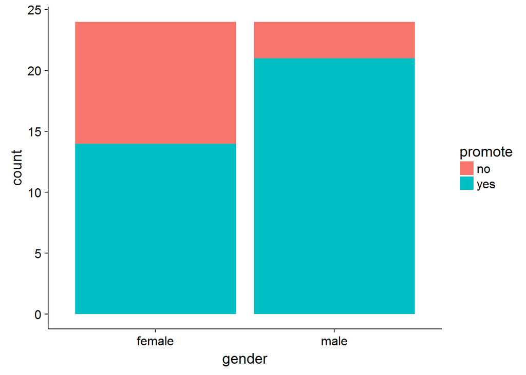

```r
### 시각화
bankstudy %>%
    ggplot(aes(x=gender, fill = promote)) +
      geom_bar()
```

## 2.2 통계적 검정

남녀간에 승진의 차별이 없다고 귀무가설($H_0$)을 설정하고 나서 이를 전통적인 방식으로 `chisq.test()` 함수를 사용해서 통계검정한다. `infer` 팩키지 `chisq_test()` 함수를 사용해서 `tidvyerse` 방식으로 깔끔하게 통계적 검정을 수행하는 것도 가능하다.

```r
## 1.3. 통계적 검정 -----
### 기본 통계검정
chisq.test(bankstudy$gender, bankstudy$promote)
```

```
    Pearson's Chi-squared test with Yates' continuity correction

data:  bankstudy$gender and bankstudy$promote
X-squared = 3.7978, df = 1, p-value = 0.05132
```

```r
### tidyverse 통계검정
bankstudy %>%
    chisq_test(promote ~ gender)
```

```
  statistic chisq_df   p_value
1  3.797802        1 0.0513199
```

## 2.3 tidyverse + 컴퓨팅 통계검정

`infer` 팩키지를 활용하여 남성과 여성간의 승진 비율에 대한 차이(`dsex_hat`)를 계산해서 기록해 둔다. 그리고 나서, 성별에 따른 승진의 차이가 없다는 귀무가설을 따르는 분포를 가정하고 남성과 여성간의 승진 비율차이를 통계량으로 계산하는 모의실험을 `1,000`회 반복한다.

`ggplot`으로 시각화하고, `p-값`을 귀무가설을 따르는 통계량과 성별의 차이에 따른 승진비율 차이를 `stat > dsex_hat` 수식으로 산출해서 계산한다.

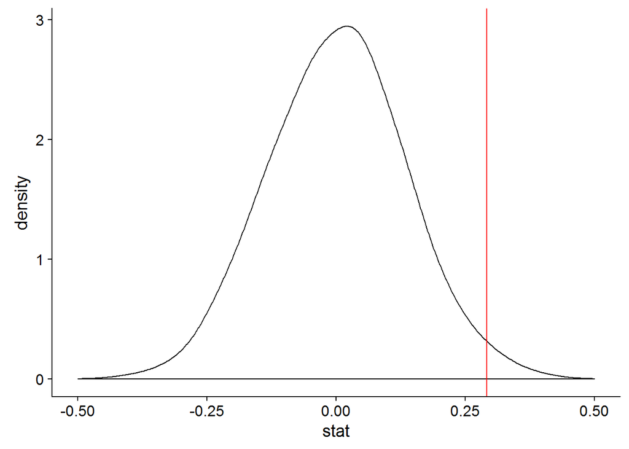

```r
### tidyverse + 컴퓨팅 통계검정
dsex_hat <- bankstudy %>%
    group_by(gender) %>%
    summarize(prob = mean(promote == "yes")) %>%
    pull(prob) %>% diff()

dsex_null <- bankstudy %>%
    specify(promote ~ gender, success = "yes") %>%
    hypothesize(null = "independence") %>%
    generate(reps = 1000, type = "permute") %>%
    calculate(stat = "diff in props", order = c("male", "female"))

ggplot(dsex_null, aes(x = stat)) +
    geom_density(bw=0.05) +
    geom_vline(xintercept = dsex_hat, color="red") +
    scale_x_continuous(limits = c(-0.5, 0.5))
```

```r
dsex_null %>%
    summarize(mean(stat > dsex_hat)) %>%
    pull() * 2
```

```
[1] 0.01
```

## 2.4 신뢰구간

`generate()` 함수의 `type`을 `permute`에서 `bootstrap`으로 바꾸고, `hypothesize()`를 제거해서 부츠트랩 표본을 산출해서 신뢰구간을 산출한다.

```r
## 1.4. 신뢰구간 -----
### tidyverse + 컴퓨팅
dsex_boot <- bankstudy %>%
    specify(promote ~ gender, success = "yes") %>%
    generate(reps = 1000, type = "bootstrap") %>%
    calculate(stat = "diff in props", order = c("female", "male"))

c(lower = dsex_hat - 2 * sd(dsex_boot$stat),
  upper = dsex_hat + 2 * sd(dsex_boot$stat))
```

```
     lower      upper
0.04571495 0.53761838
```

```r
### 전통적 방식
# n <- nrow(bankstudy)
# dsex_prop <- bankstudy %>%
#     group_by(gender) %>%
#     summarize(prob = mean(promote == "yes")) %>%
#     pull(prob)
#
# prop.test(x=c(dsex_prop[2], dsex_prop[1]) * n, n = c(n, n),  alternative = "two.sided", correct=FALSE) %>%
#     broom::tidy()
```

# 3 신약효과 사례연구

`http://bit.ly/2mDUX9K` 사이트에서 `infer` 팩키지 사례로 자주 언급되는 신약효과 데이터를 다운로드 받는다. 신약효과 사례연구는 실험군과 대조군간의 신약효과가 있는지를 검정하는 `t-검정`의 사례로 사용된다.

```r
# 2. 신약 효과 -----
## 1.1. 데이터 -----
load(url("http://bit.ly/2mDUX9K"))
```

## 3.1 탐색적 데이터 분석

신약효과 데이터는 범주형 변수 1개와 연속형변수 1개로 구성되고, 12행으로 구성되어 있어, 기술통계량 비율도 뽑아보고, `ggplot`으로 시각화해서 데이터와 친숙해진다.

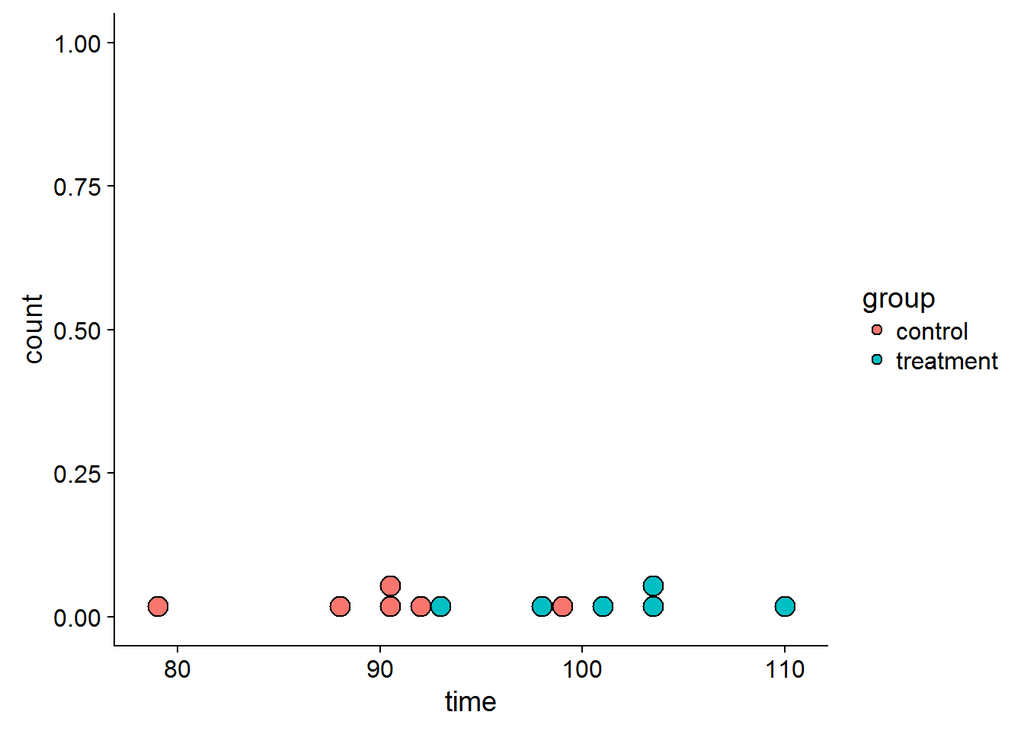

```r
## 1.2. EDA -----
### 시각화
ggplot(drugstudy, aes(x = time, fill = group)) +
    geom_dotplot()
```

```r
### 기술통계량
drugstudy %>%
    group_by(group) %>%
    summarise(mean(time))
```

```
# A tibble: 2 x 2
  group     `mean(time)`
  <fct>            <dbl>
1 control           89.8
2 treatment        102.
```

## 3.2 통계적 검정

실험군과 대조군간에 신약효과가 없다는 귀무가설($H_0$)을 설정하고 나서 이를 전통적인 방식으로 `t.test()` 함수를 사용해서 통계검정한다. `infer` 팩키지 `t.test()` 함수를 사용해서 `tidvyerse` 방식으로 깔끔하게 통계적 검정을 수행하는 것도 가능하다.

```r
## 1.3. 통계적 검정 -----
### 기본 통계검정
g1 <- drugstudy %>%
    filter(group == "treatment") %>%
    select(time) %>%  pull

g2 <- drugstudy %>%
    filter(group == "control") %>%
    select(time) %>%  pull

t.test(g1, g2, conf.level = 0.95, alternative = "two.sided")
```

```
    Welch Two Sample t-test

data:  g1 and g2
t = 3.294, df = 9.857, p-value = 0.008251
alternative hypothesis: true difference in means is not equal to 0
95 percent confidence interval:
  3.759464 19.573869
sample estimates:
mean of x mean of y
101.50000  89.83333
```

```r
### tidyverse 통계검정
drugstudy %>%
    t_test(time ~ group)
```

```
  statistic     t_df     p_value alternative
1 -3.293981 9.856968 0.008250683   two.sided
```

## 3.3 tidyverse + 컴퓨팅 통계검정

`infer` 팩키지를 활용하여 실험군과 대조군간에 대한 차이(`drug_diff_hat`)를 계산해서 기록해 둔다. 그리고 나서, 실험군과 대조군간 신약효과가 없다는 귀무가설을 따르는 분포를 가정하고 실험군과 대조군간의 신약효과 차이를 통계량으로 계산하는 모의실험을 `1,000`회 반복한다.

`ggplot`으로 시각화하고, `p-값`을 귀무가설을 따르는 통계량과 실험군과 대조군간의 신약효과 차이를 `stat > drug_diff_hat` 수식으로 산출해서 계산한다.

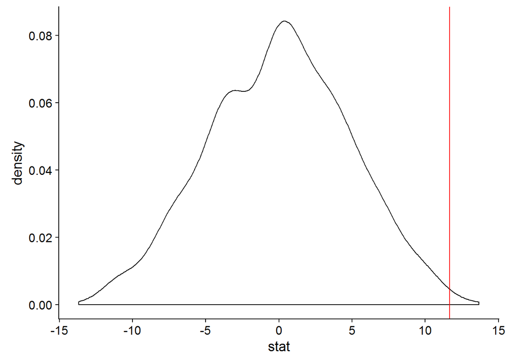

```r
### tidyverse + 컴퓨팅 통계적 검정
drug_diff_hat <- drugstudy %>%
    group_by(group) %>%
    summarize(xbar = mean(time)) %>%
    pull(xbar) %>%
    diff()

drug_null <- drugstudy %>%
    specify(time ~ group) %>%
    hypothesize(null = "independence") %>%
    generate(reps = 1000, type = "permute") %>%
    calculate(stat = "diff in means", order = c("treatment", "control"))

ggplot(drug_null, aes(x = stat)) +
    geom_density() +
    geom_vline(xintercept = drug_diff_hat, color="red")
```

```r
drug_null %>%
    summarize(mean(stat > drug_diff_hat)) %>%
    pull() * 2
```

```
[1] 0.006
```

## 3.4 신뢰구간

`generate()` 함수의 `type`을 `permute`에서 `bootstrap`으로 바꾸고, `hypothesize()`를 제거해서 부츠트랩 표본을 산출해서 신뢰구간을 산출한다.

```r
## 1.4. 신뢰구간 -----
drug_boot <- drugstudy %>%
    specify(time ~ group) %>%
    generate(reps = 1000, type = "bootstrap") %>%
    calculate(stat = "diff in means", order = c("treatment", "control"))

c(lower = drug_diff_hat - 2 * sd(drug_boot$stat),
  upper = drug_diff_hat + 2 * sd(drug_boot$stat))
```

```
    lower     upper
 4.850624 18.482709
```

[^1]: [William Surles (2017-09-11), “Foundations of Inference”](http://rstudio-pubs-static.s3.amazonaws.com/308326_f3706219dfb14ccd8f530185631e8abf.html)
[^2]: [Chester Ismay(2018-05-14), “Chi-squared test example using nycflights13 flights data”](https://cran.r-project.org/web/packages/infer/vignettes/chisq_test.html)
[^3]: [Chester Ismay (2018-05-14), “Two sample t test example using nycflights13 flights data”](https://cran.r-project.org/web/packages/infer/vignettes/two_sample_t.html)